# Corona Sweeper

Kate Saunders

12/11/2020

# Game Design

## Game Rules

### Game Summary

The goal of the game is to use testing to discover people within the population who are infected, and to stop the virus spreading. Hidden infectious people will be revealed to you if (i) you find them via testing, or (ii) they develop symptoms. You will be able to test if a person has the virus using a mouse click. If they are infected they will go into quarantine along with their four closest neighbours.

Each new mouse click also starts a new day. Upon each new day, undiscovered infectious people within the population can infect others. In addition to testing, to help you discover these people, if a person develops symptoms they are automatically quarantined along with their direct neighbours. Once in quarantine a person can't infect anyone else.

You win the game by finding and quarantining all infections through the use of testing. You lose the game though if the virus takes off in the population and over half of the people contract the virus.

### Virus Behaviour

For this game, a person is classfied as one of following infectious states:

| Label | Letter | Description |
| --- | --- | --- |
| Susceptible | S | Can catch the virus |
| Infected | I | Has caught the virus |
| Recovered | R | No longer has the virus |

If a person who is susceptible comes into contact with an infected person they have a chance of catching the virus. If the person catches the virus then their status changes to infected. People who no longer have the the virus are considered recovered. Once a person has recovered they don't return to a susceptible state and can not become infected again. Labelling the state as recovered avoids including a mortality state.

### Quarantine

There is a fourth state a person can be, the exposed state. Exposed people, have come into contact with an infected person, but don't know yet if this exposure has caused them to catch the virus. To prevent the spread of the virus, anyone exposed to the virus is automatically quarantined.

### Hidden Infections

The game begins with four randomly chosen people who are infected but their infection status is hidden. Until these hidden infectious people are found and quarantined, they will continue to lead to new infections and the virus will spread.

### Catching the Virus

A susceptible person can catch the virus from an infected person who is a neighbour. As the game is played in a grid neighbours are located left, right, top and bottom.

Infections occur based on a random trial. For example, a susceptible person might catch the virus from their infected neighbour with a 1 in 5 chance (default). To make the game easier or harder this probability of infection can be changed using the levels. Infections also occur independently of each other, so if two or more neighbours are infected, than a susceptible person is much more likely to catch the virus.

Also to keep things interesting the board wraps top to bottom and left to right. A person in the bottom row can infect therefore their equivalent neighbour in the top row and vice versa. Similarly a person in the far left column can infect their equivalent neighbour in the far right column, and vice versa.

### Testing

To stop the virus spreading, testing can be used to find the hidden people in the population who are infected. A tested person who is revealed as infected is automatically quarantined along with their neighbours. Careful however, a person who was tested today and doesn't have the virus can still get infected at some time in the future. It therefore may be necessary to test a person more than once.

### Symptoms and Recovery

In addition to testing, a person is revealed as infected and quarantined if they start showing symptoms. On average the WHO says symptoms will show after 5-6 days. https://www.who.int/emergencies/diseases/novel-coronavirus-2019/question-and-answers-hub/q-a-detail/q-a-coronaviruses In the game, a person will therefore show symptoms after a random number of days, with the average time until symptoms being 5 days. Once symptoms are revealed, that person and their four neighbours are quarantined.

The WHO also says people with mild cases are expected to recover within two weeks https://www.who.int/dg/speeches/detail/who-director-general-s-opening-remarks-at-the-media-briefing-on-covid-19---24-february-2020 Similarly, the number of days until a person recovers is randomly simulated, with an average recovery period of 14 days.

## R Set Up

This section provides the R code needed to initialise the game variables and parameters.

### Contact Network

We store all the information about the people in a data frame called `init_data`, including details about a person's infection status, quarantine status and test status. This data frame also gives the location of people within a grid. This grid forms the game board and the contact network.

```r
# board dimensions (rows by columns)
I = 20; J = 20;

# initialise the board
init_data <- expand.grid(X = 1:I, Y = 1:J) %>% as.data.frame()
```

### Infectious Status

There is a column for a person's known infection status, and to start everyone in labelled as susceptible.

```r
infection_levels = c("S", "I", "R")
infection_labels = c("Susceptible", "Infected", "Recovered")
init_data$shown = rep("S", nrow(init_data))
```

### Hidden Infectious Status

There is another column that stores the hidden infectious status. In the beginning of the game, four people are randomly set to be infectious.

```r
start_num_infections = 4
init_data$hidden <- rep("S", I*J)
initial_infections <- sample(1:(I*J), start_num_infections)
init_data$hidden[initial_infections] <- "I"
```

### Quarantine Status

Everyone begins the game not in quarantine.

```r
quarantine_levels = c("Yes", "No")
quarantine_labels = c("Quarantined", "No Restrictions")
init_data$quarantined <- rep("No", I*J)
```

### Testing

Everybody begins the game as untested.

```r
test_levels = c("tested", "unknown")
test_labels = c("Tested", "Not Tested")
init_data$tested <- rep("unknown", I*J)
```

### Infection Period

We also store a variable called infection time. This will be used to keep track of when a person becomes infected, when their symptoms will be revealed and when they will recover. The infection time is not shown the game player and is for internal use only. At the beginning of the game, the infection period is set to NA for all people, expect for the four people randomly infected and their infection time is set to zero.

```r
# Infection time
init_data$infection_period <- rep(NA, I*J)
init_data$infection_period[initial_infections] <- 0
```

### Symptoms and recovery

The time until the symptoms arrive and the time until a patient recovery is randomly simulated. For this we use Poisson random variables. Not everyone will get infected, however it simplifies things to initialise these symtpom and recovery variables for everyone before the game starts.

```r
symptom_lambda = 5
init_data$symptom_time <- rpois(I*J, lambda = symptom_lambda)

recovery_lambda = 14
init_data$recovery_time <- init_data$symptom_time + rpois(I*J, lambda = recovery_lambda)
```

### Initialise person data frame

These steps are wrapped in a function called `initialise_person_statuses()`.

```r
# A function to initialise the game board
initialise_person_statuses <- function(I, J, start_num_infections,
                                  symptom_lambda, recovery_lambda){

  # Initialise grid and displayed infection status
  init_data <- expand.grid(X = 1:I, Y = 1:J)
  init_data$shown <- rep("S", I*J)

  # Initialise quarantine state
  init_data$quarantined <- rep("No", I*J)

  # Initialise test state
  init_data$tested <- rep("unknown", I*J)

  # Randomly initialise the hidden infections
  init_data$hidden <- rep("S", I*J)
  initial_infections <- sample(1:(I*J), start_num_infections)
  init_data$hidden[initial_infections] <- "I"

  # Initialise the infection time
  init_data$infection_period <- rep(NA, I*J)
  init_data$infection_period[initial_infections] <- 0

  # Randomly initialise the time until symptoms show
  init_data$symptom_time <- rpois(I*J, lambda = symptom_lambda)

  # Randomly initialise the time until recovery
  init_data$recovery_time <- init_data$symptom_time + rpois(I*J, lambda = recovery_lambda)

  return(init_data)

}
```

### Neighbours

We also need another function get the four closest neighbours. This will be needed for both simulating infections and quarantining. A couple of important design points about finding the neighbours are:

- The board positions are stored as vector
- The grid cells are vectorised by column first then rows
- The board wraps like a taurus, so the top row neighbours the bottom row, and the far left row neighbours the far right row. The `get_neighbours()` function takes a location with the vector that indexes the grid/game board, and returns the vectorised positions of its neighbours. Note within this function, the later part of each `*_nbr` equation addresses the grid wrapping and deals with the boundary cases.

```r
get_neighbours <- function(i, I, J){
  row_index = i%%I + I*(i%%I == 0);
  col_index = ceiling(i/I)
  left_nbr   = i - I + (col_index == 1)*(I*J)
  right_nbr  = i + I - (col_index == J)*(I*J)
  top_nbr    = i - 1 + (row_index == 1)*I
  bottom_nbr = i + 1 - (row_index == I)*I
  nbrs <- c(left_nbr, right_nbr, top_nbr, bottom_nbr)
  return(nbrs)
}
```

All the tools needed to introduce the virus dynamics have now been introduced.

## Virus Dynamics

### Each New Day

With each new day the following must happen:

- Increase counter on infection period
- Identify exposures
- Update with new infections
- Reveal those with symptoms
- Reveal those who recovered
- Reveal status of the person tested
- Quarantine those exposed

We will therefore be updating the data frame containing all the information about the people.

```r
person_data <- initialise_person_statuses(I = 20, J = 20, start_num_infections = 4, symptom_lambda = 5, recovery_lambda = 14)
```

### Update infection period

The time a person has been infected needs to increase by 1.

```r
 # Increase counter on infection period
  infectious_cases = (person_data$hidden == "I")
  person_data$infection_period[infectious_cases] =
    person_data$infection_period[infectious_cases] + 1
```

### Identify exposures

We need to identify the hidden infected people who can infect others and subsequently identify anyone who has been exposed to the virus. We are not interested in neighbours already in quarantine, as we are assuming under strict quarantine conditions they can not catch the virus.

```r
 # Get neighbours of infected people
  i = which(person_data$hidden == "I" &
            person_data$quarantined == "No")
  neighbours = get_neighbours(i, I, J)
  already_quarantined = which(person_data$quarantined == "Yes")
  exceptions = c(i, already_quarantined)
  contacts = neighbours[!(neighbours %in% exceptions)]
```

### Update with new infections

Once the susceptible people who have been exposed to an infected person have been identified, the new infections can randomly simulated. How an infection occurs between a susceptible and infected person is modelled using a Bernoulli random variable. Bernoulli variables have two possible outcomes, such as heads or tails, yes or no, or, true or false. In our case, these two states are infected or not infected. If you are performing multiple Bernoulli trials, then this is equivalent to a binonmial variable, for example, how many heads in 10 coin flips, or how many infections occur amongst the exposed contacts. To simulate the infections of those exposed the function `rbinom()` is used. If a person is newly infected their `hidden` status needs to be updated and the `infection_period` needs to be set to 0.

```r
  # Update with new infections
  infection_prob = 1/5
  new_infections = rbinom(length(contacts), 1, infection_prob)
  infected_contacts = unique(contacts[which(new_infections == 1)])
  person_data$hidden[infected_contacts] = "I"
  person_data$infection_period[infected_contacts] = 0
```

### Reveal those with symptoms

If a person has developed symptoms, they are to be revealed to the player and their `shown` infection status needs to be updated.

```r
  # Reveal those with symptoms
  known_cases = (person_data$infection_period > person_data$symptom_time)
  person_data$shown[known_cases] = "I"
```

### Reveal those who recovered

Similarly, if a person has recovered then their infection status also needs to be updated.

```r
# Reveal those who recovered
  recovered_cases = (person_data$infection_period > person_data$recovery_time)
  person_data$hidden[recovered_cases] = "R"
  person_data$shown[recovered_cases] = "R"
```

### Reveal status of the person tested

When a person is tested their test status needs to be updated and their hidden status needs to be revealed. In the game a mouse click will be used to provide a the coordinates of the person tested. Here we have used example coordinates of (1,1) just to show how this code chunk works.

```r
# Example of a test coordinate (1,1)
test_x = 1; test_y = 1;

# Reveal status of the person tested
  vec_ref = (test_y-1)*J + test_x
  person_data$tested[vec_ref] = "tested"
  person_data$shown[vec_ref] = person_data$hidden[vec_ref]
```

### Quarantine those exposed

If the person tested was infected or if new people have shown symptoms, then these people need to into quarantine along with their neighbours.

```r
# Quarantine those exposed
  i = which(person_data$shown == "I")
  isolating = c(i, get_neighbours(i, I, J))
  person_data$quarantined[isolating] = "Yes"
```

### Infection Update

These steps can be wrapped in a function called `update_person_statuses()`.

```r
update_person_statuses <- function(person_data, I, J,
                                   infection_prob,
                                   test_x, test_y){

  # Increase counter on infection period
  infectious_cases = (person_data$hidden == "I")
  person_data$infection_period[infectious_cases] =
    person_data$infection_period[infectious_cases] + 1

  # Get neighbours of infected people
  i = which(person_data$hidden == "I" &
            person_data$quarantined == "No")
  neighbours = get_neighbours(i, I, J)
  already_quarantined = which(person_data$quarantined == "Yes")
  exceptions = c(i, already_quarantined)
  contacts = neighbours[!(neighbours %in% exceptions)]

  # Update with new infections
  new_infections = rbinom(length(contacts), 1, infection_prob)
  infected_contacts = unique(contacts[which(new_infections == 1)])
  person_data$hidden[infected_contacts] = "I"
  person_data$infection_period[infected_contacts] = 0

  # Reveal those with symptoms
  known_cases = (person_data$infection_period > person_data$symptom_time)
  person_data$shown[known_cases] = "I"

  # Reveal those who recovered
  recovered_cases = (person_data$infection_period > person_data$recovery_time)
  person_data$hidden[recovered_cases] = "R"
  person_data$shown[recovered_cases] = "R"

  # Reveal status of the person tested
  vec_ref = (test_y-1)*J + test_x
  person_data$tested[vec_ref] = "tested"
  person_data$shown[vec_ref] = person_data$hidden[vec_ref]

  # Quarantine those exposed
  i = which(person_data$shown == "I")
  isolating = c(i, get_neighbours(i, I, J))
  person_data$quarantined[isolating] = "Yes"

  return(person_data)

}
```

The next step is to set up the game board. After this, how the mouse click is used for testing and how the game board updates with a mouse click can be explained.

## Board Design

Below is the code needed to create the `ggplot` game board. Hopefully, it looks clean and simple, but it actually took some thinking!

### Board

The board is designed to resemble the standard minesweeper board. This can be achieved in a range of ways, but here grid coordinates are plotted used `geom_point()` and a square shape, `shape = 15`.

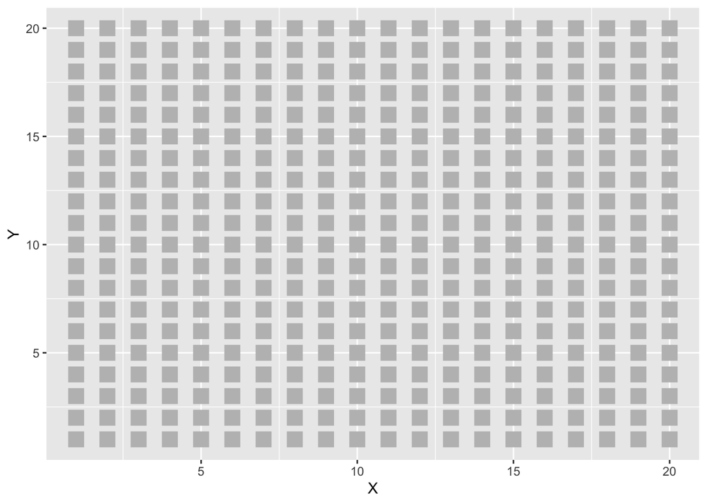

```r
library(ggplot2)
# plot the board
pnt_size = 3
ggplot(data = init_data) +
    geom_point(aes(x = X, y = Y), col = "gray", shape = 15, size = pnt_size + 2)
```

### Infectious Status

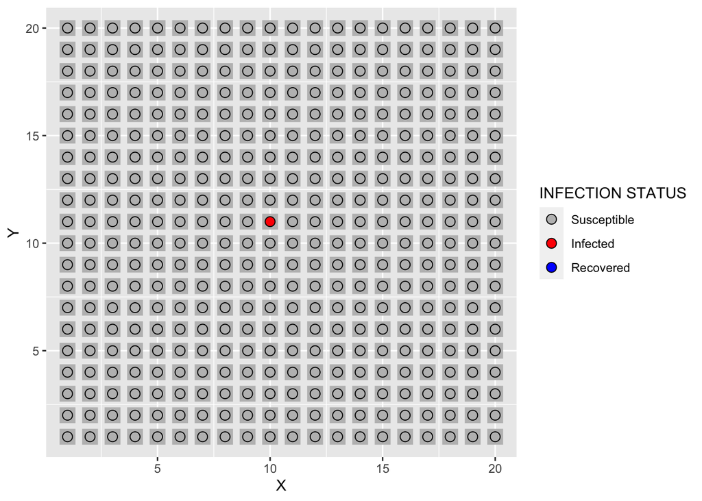

```r
# infected example
centre_cell = I*(J/2) + J/2
init_data$shown[centre_cell] = "I"

# for the plot legend
init_data$shown <- factor(init_data$shown, levels = infection_levels)

# plot the board with susceptible states
ggplot(data = init_data) +
  geom_point(aes(x = X, y = Y), col = "gray", shape = 15, size = pnt_size + 2) +
  geom_point(aes(X, Y, fill = shown), shape = 21, size = pnt_size) +
  scale_fill_manual("INFECTION STATUS", labels = infection_labels,
                      values = c("S" = "gray", "I" = "red", "R" = "blue"),
                      drop = FALSE)
```

At the beginning of the game not all susceptible states will be visible. We want to keep the legend constant and to show all possible states at all times. This is why we convert the `shown` state to a factor instead of a string, and use `drop = FALSE` when we create our legend.

You might also notice, there is both a levels and labels vector. The levels keep the internal code concise and clear and the labels are for what will appear in the plot legend.

### Quaratine

The undelying grid squares are used to show if a person is in quarantine or not. These squares are made slightly transparent using `alpha` so the susceptible state is clearly distinguishable from the quarantine state. Again as an example, the infected central cell is quarantined along with its neighbours.

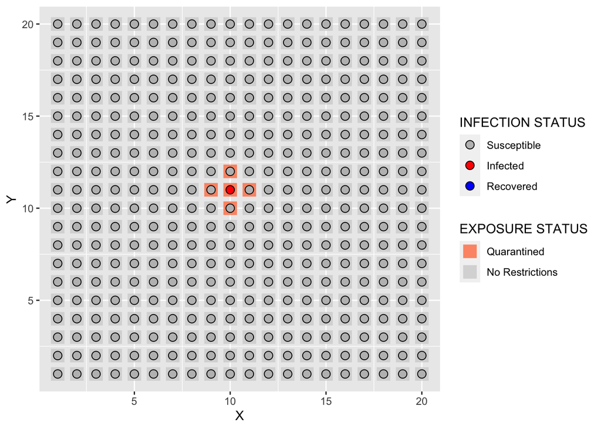

```r
# quarantine example
nbrs = get_neighbours(centre_cell, I, J)
init_data$quarantined[c(centre_cell, nbrs)] = "Yes"

# for the plot legend
init_data$quarantined <- factor(init_data$quarantined, levels = quarantine_levels)

# plot the board with susceptible and quarantine states
ggplot(data = init_data) +
    geom_point(aes(x = X, y = Y, col = quarantined),
               shape = 15, size = pnt_size + 2, alpha = 0.8) +
    scale_color_manual("EXPOSURE STATUS", labels = quarantine_labels,
                         values = c("No" = "lightgray", "Yes" = "coral"),
                         drop = FALSE) +
    geom_point(aes(X, Y, fill = shown), shape = 21, size = pnt_size) +
    scale_fill_manual("INFECTION STATUS", labels = infection_labels,
                        values = c("S" = "gray", "I" = "red", "R" = "blue"),
                        drop = FALSE)
```

### Testing

We also need to visualise if a person has been tested we use `geom_point()` and a circle with a cross, `shape = 13`. If a person hasn't been tested it just appears as the normal black circle outline, `shape = 1`.

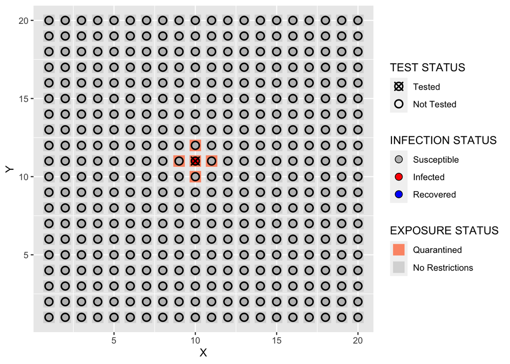

```r
# test example
init_data$tested[centre_cell] = "tested"

# for the plot legend
init_data$tested <- factor(init_data$tested, levels = test_levels)

# plot the board with susceptible, quarantine and test states
board <- ggplot(data = init_data) +
    geom_point(aes(x = X, y = Y, col = quarantined), shape = 15,
               size = pnt_size + 2, alpha = 0.8) +
    scale_color_manual("EXPOSURE STATUS", labels = quarantine_labels,
                         values = c("No" = "lightgray", "Yes" = "coral"),
                         drop = FALSE) +
    geom_point(aes(X, Y, fill = shown), shape = 21, size = pnt_size) +
    scale_fill_manual("INFECTION STATUS", labels = infection_labels,
                        values = c("S" = "gray", "I" = "red", "R" = "blue"),
                        drop = FALSE) +
    geom_point(aes(X, Y, shape = tested), size = pnt_size, stroke = 1) +
    scale_shape_manual("TEST STATUS", labels = test_labels,
                         values = c("unknown" = 1, "tested" = 13),
                         drop = FALSE)
board
```

### Tweaking the aesthetics

At this point it is worth noting that the symbols have been carefully selected so all three states can be visualised simultaneously; exposure (colour), susceptibility (fill) and test (shape). Also note that the order the `geom_point()` calls are included is important for the order in which they are layered.

A few small fixes also make the game much more aesthetically pleasing

- `coord_fixed()` will ensure the geom_shape() will display as squares.
- `theme_minimal()` is a cleaner and more simplistic theme
- `axis.*()` can be used to remove the axes text and labels
- `legend.*()` can be used to change the legend position and text
- `guides()` can be used to order the position of the legend elements

Positioning the legend at the bottom improves the display on mobile devices.

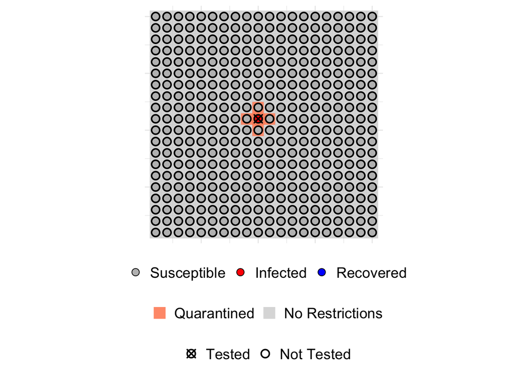

```r
board <- board +
  coord_fixed() +
      theme_minimal() +
      theme(
        axis.text = element_blank(), axis.title = element_blank(),
        legend.position = "bottom", legend.box = "vertical",
        legend.title = element_blank(), legend.text = element_text(size = 14)) +
      guides(fill = guide_legend(order=1),
              col = guide_legend(order=2),
              shape = guide_legend(order=3))
board
```

### Produce Plot

```r
# A function to plot the game board
produce_board_plot <- function(plot_df,
                       quarantine_labels, quarantine_levels,
                       infection_labels, infection_levels,
                       test_labels, test_levels){

  plot_df$shown <- factor(plot_df$shown, levels = infection_levels)
  plot_df$hidden <- factor(plot_df$hidden, levels = infection_levels)
  plot_df$quarantined <- factor(plot_df$quarantined, levels = quarantine_levels)
  plot_df$tested <- factor(plot_df$tested, levels = test_levels)

  pnt_size = 3.5
  board_plot <- ggplot(plot_df) +
    geom_point(aes(x = X, y = Y, col = quarantined),
               shape = 15, size = pnt_size + 2, alpha = 0.8) +
    scale_color_manual("EXPOSURE STATUS",
                       labels = quarantine_labels,
                       values = c("No" = "lightgray", "Yes" = "coral"),
                       drop = FALSE) +
    geom_point(aes(X, Y, fill = shown),
               shape = 21, size = pnt_size) +
    scale_fill_manual("INFECTION STATUS",
                      labels = infection_labels,
                      values = c("S" = "gray", "I" = "red", "R" = "blue"),
                      drop = FALSE) +
    geom_point(aes(X, Y, shape = tested), size = pnt_size, stroke = 1) +
    scale_shape_manual("TEST STATUS",
                       labels = test_labels,
                       values = c("unknown" = 1, "tested" = 13),
                       drop = FALSE) +
    coord_fixed() +
    theme_minimal() +
    theme(axis.text = element_blank(),
          axis.title = element_blank(),
          legend.position = "bottom",
          legend.box = "vertical",
          legend.title = element_blank(),
          legend.text = element_text(size = 14),
          title = element_text(size = 16, hjust = 0.5)) +
    guides(fill = guide_legend(order=1),
           col = guide_legend(order=2),
           shape = guide_legend(order=3))

  return(board_plot)

}
```

## Shiny

The shiny basics needed to create the interactivity of the game are outlined here. This shiny information is not covered in a comprehensive way. For more shiny details these [tutorials](https://shiny.rstudio.com/tutorial/written-tutorial/lesson1/) are highly recommended.

### App File

Create a new function called `app.R`. This will be the function that contains the code to builds the shiny app.

### Static Game Objects

To keep the code clean, all statics objects are grouped the beginning of the function, `app.R`. These are packages, variables and functions that will not be updated with the mouse click..

```r
# Load packages
library(shiny)
library(ggplot2)
library(shinyalert)
```

Initialise the game parameters for the virus behaviour, board setup and difficulty levels.

```r
# Initialise parameters
start_num_infections = 4
symptom_lambda = 5
recovery_lambda = 14
I = 20;
J = 20;
infection_levels = c("S", "I", "R")
infection_labels = c("Susceptible", "Infected", "Recovered")
test_levels = c("tested", "unknown")
test_labels = c("Tested", "Not Tested")
quarantine_levels = c("Yes", "No")
quarantine_labels = c("Quarantined", "No Restrictions")
default_prob = 0.2
```

Load the functions needed to set up the game and update the virus dynamics. These functions are saved in a separate file in the working directory.

```r
# Load functions
source("initialisePersonStatuses.r")
source("produceGameBoard.r")
source("getNeighbours.r")
source("updatePersonStatuses.r")
```

### Basic Shiny Set Up

A shiny app needs two core functions to work, a User Interface (UI) and a Server. In the user interface you specify the app layout, ie a where the plot should be, and in the server you specify what the plot should look like. An example Shiny set up for a plot is below. There is no interactivity specified yet.

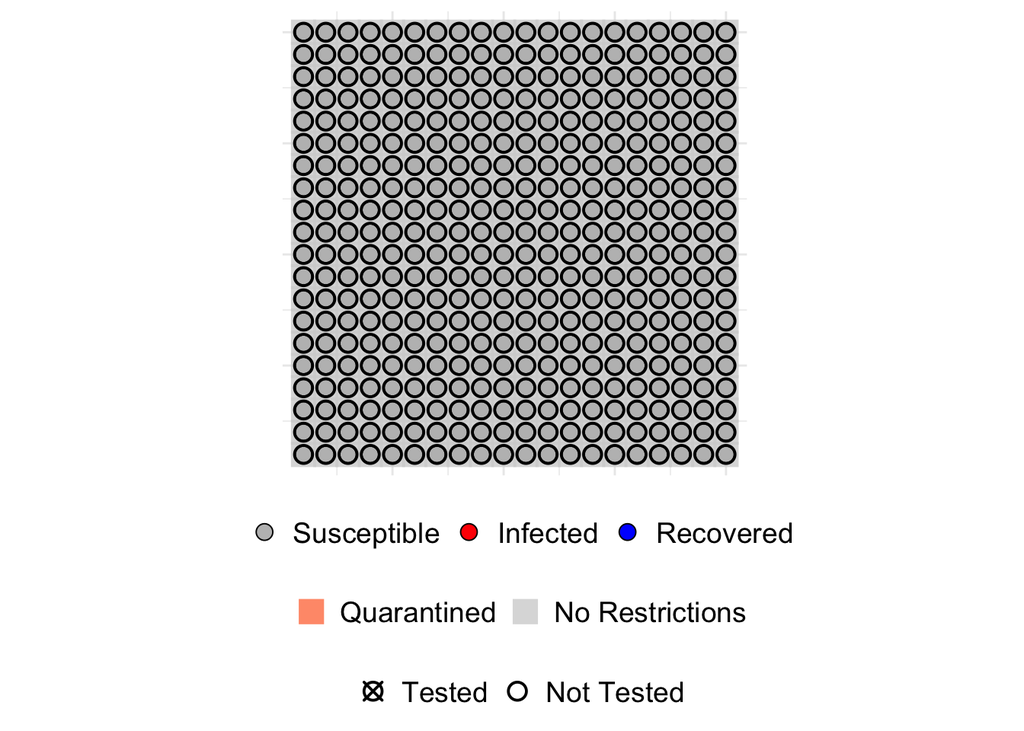

```r
ui <- basicPage(
  plotOutput("plotBoard", click = NULL)
)

server <- function(input, output){

  # Initialise data frame for people
  person_data = initialise_person_statuses(I, J,  start_num_infections, symptom_lambda, recovery_lambda)

  # Plot of the game board
  output$plotBoard <- renderPlot({

     produce_board_plot(person_data,
                       quarantine_labels, quarantine_levels,
                       infection_labels, infection_levels,
                       test_labels, test_levels)

  })

}

shinyApp(ui, server)
```

### Mouse Click & Reactivity

The goal of the following code snippets is to show how to use the mouse click to test if a person is infected, update the infections and update the plot. This requires three basic edits to the above code.

#### (i) Mouse click variable

To get coordinates from a plot in shiny we can simply change the `plotOutput()` function in the user interface. All is needed here is to change the input `click = NULL` to `click = "plot_click"`.

```r
ui <- basicPage(
  plotOutput("plotExample", click = "plot_click")
  )
```

Now a variable called `input$plot_click` is created that contains the click coordinates.

#### (ii) Reactive variables

In the shiny `server()` for variables to change when something happens, like a mouse is click, these variables need to be defined as `reactiveValues()`.

In this game, when the mouse is clicked two variables need to update, the test coordinate and the data frame storing the infection states. We have redefined these variables below.

```r
server <- function(input, output){

  # Set up game board
  init_data = initialise_person_statuses(I, J, start_num_infections,
                                   symptom_lambda, recovery_lambda)

  # Initialise the reactive variables
  test_coord <- reactiveValues(x = NULL, y = NULL)
  person_data <- reactiveValues(infections = init_data)

  # ...

}
```

These variables can now be called within the server function using `test_coord$x`, `test_coord$y` and `person_data$infections`. Before any mouse click occurs, the `test_coord` is set as `NULL` and the `person_data` is set as the initial values provided by `initialise_person_statuses()`.

#### (iii) Observe the Mouse Click

When the mouse click happens, `input$plot_click` is updated. Shiny can be told this using `observeEvent(input$plot_click, {...})`. Any reactive variables definied within the `observeEvent()` function will then be called to update.

```r
server <- function(input, output){

  # Set up game board
  init_data = initialise_person_statuses(I, J, start_num_infections,
                                   symptom_lambda, recovery_lambda)

  # Initialise the reactive variables
  test_coord <- reactiveValues(x = NULL, y = NULL)
  person_data <- reactiveValues(infections = init_data)

  # Observe the mouse click
  observeEvent(input$plot_click, {

    # Update test coordinate
    x = round(as.numeric(input$plot_click$x))
    x = max(1, x);
    x = min(x, I);
    test_coord$x = x

    y = round(as.numeric(input$plot_click$y))
    y = max(1, y);
    y = min(y, J);
    test_coord$y = y

    # Simulate new infections and update infection statuses
    person_data$infections = update_person_statuses(person_data$infections, I, J, default_prob,
                           test_coord$x, test_coord$y)

  })

  # Plot of the game board
  output$plotBoard <- renderPlot({

    produce_board_plot(person_data$infections,
                       quarantine_labels, quarantine_levels,
                       infection_labels, infection_levels,
                       test_labels, test_levels)

  })

}
```

Here the inputs of `update_person_statuses()` and `produce_board_plot()` have changed to include the relevant reactive values.

Coordinates from the plot are converted to numeric values and rounded to give the integer coordinates that correspond to a grid. Mouse clicks outside the plot are also rounded to the nearest valid integer values.

### Infection probabiliy

#### (i) Add slider

To understand the game dynamics it can be useful to change the probability of infection. Given this, it would be nice to add a `sliderInput()`. The below code will position a slider underneath the plot.

```r
ui <- basicPage(
  plotOutput("plotBoard", click = "plot_click"),
  sliderInput("prob", "Infection Probability:",
              min = 0, max = 0.5, value = default_prob) #this line here
)
```

#### (ii) Updates for when the probability changes

This creates a new variable called `input$prob` that corresponds to the slider infection probability. When the slider changes this event needs to be observed by Shiny, then the person statuses and correspondingly the whole board should reset.

```r
server <- function(input, output) {

  # ...

  # Update with slider change
  observeEvent(input$prob,{
    person_data$infections = initialise_person_statuses(I, J, start_num_infections, symptom_lambda, recovery_lambda)

  })

  # ...

}
```

One small further edit is needed. The slider input `input$prob` needs to be passed to the function `update_person_statuses()` so how the infections are simulated will also change with the slider value.

```r
  # Observe the mouse click
  observeEvent(input$plot_click, {

    # ...
    person_data$infections = update_person_statuses( person_data$infections, I, J, input$prob, test_coord$x, test_coord$y)

  # ...

  }
```

### Rules

It addition to different levels, it is nice to add some rules to the game and this can be done by calling `verbatimTextOutput()` within the user interface.

```r
ui <- basicPage(
  plotOutput("plotBoard", click = "plot_click"),
  sliderInput("prob", "Infection Probability:",
              min = 0, max = 0.5, value = default_prob),
  verbatimTextOutput("rules") # this line here
)
```

The corresponding text to print, `output$rules`, needs to be defined in the server using the function `renderText()`.

```r
server <- function(input, output) {

  # ...

output$rules <- renderText({
      paste0("Add your text about your rules! \n ",
             "Didn't write them in full here to keep things short")
  })

  # ...

}
```

### Winning

To win the game all hidden infections must be identified and revealed. The game is lost if over half of the population from becomes infected, even if some of them recover. To keep track of when the game is won or lost more reactive variables need to be initialised.

```r
server <- function(input, output) {

  # ...

    counter <- reactiveValues(countervalue = 0)
    game_summary <- reactiveValues(num_I_hidden = start_num_infections,
                                 num_I_shown = 0,
                                 num_R = 0)

  # ...

}
```

Upon each mouse click these variables need to update and whether the game is won or lost evaluated.

```r
  # Observe the mouse click
  observeEvent(input$plot_click, {

    # ...

    # Increase counter on infection period
    counter$countervalue <- counter$countervalue + 1

    # ....

     # Game stats
    game_summary$num_I_shown = sum(person_data$infections$shown == "I")
    game_summary$num_I_hidden = sum(person_data$infections$hidden == "I")
    game_summary$num_R = sum(person_data$infections$shown == "R")
    game_win = (game_summary$num_I_shown == game_summary$num_I_hidden)
    game_loss = ((game_summary$num_I_hidden + game_summary$num_R) > I*J*perc)

    # ...

  }
```

#### Pop Up Box

When the game is won or lost a pop up box should appear. For this the package `shinyalert` is needed and was loaded earlier. Within the user interface `useShinyalert()` needs to be added to generate the pop up.

```r
ui <- basicPage(
  useShinyalert(), # this line here
  verbatimTextOutput("summaryText"),
  plotOutput("plotBoard", click = "plot_click"),
  sliderInput("prob", "Infection Probability:",
              min = 0, max = 0.5, value = default_prob)
)
```

To define the text in the pop up box the function `shinyalert()` is called within the server. Two different pop ups are defined for if the game is won or lost.

```r
  # Observe the mouse click
  observeEvent(input$plot_click, {

    # ...

     # Game stats
    game_summary$num_I_shown = sum(person_data$infections$shown == "I")
    game_summary$num_I_hidden = sum(person_data$infections$hidden == "I")
    game_summary$num_R = sum(person_data$infections$shown == "R")
    game_win = (game_summary$num_I_shown == game_summary$num_I_hidden)
    game_loss = ((game_summary$num_I_hidden + game_summary$num_R) > I*J*perc)

    # Game end
    if(game_win)
      shinyalert(title = "You did it! \n All infections are quarantined", type = "success")
    if(game_loss)
      shinyalert(title = "Sorry you failed. \n The spread escaped", type = "info")

    # ...

  }
```

#### Game Stats

To help people know how many infections are hidden and perhaps change their testing strategy, it would be nice to add the game statistics to the top as a print statement. For this `verbatimTextOutput()` is called and the summary text is positioned above the game board.

```r
ui <- basicPage(
  useShinyalert(),
  verbatimTextOutput("summaryText"), # this line here
  plotOutput("plotBoard", click = "plot_click"),
  sliderInput("prob", "Infection Probability:",
              min = 0, max = 0.5, value = default_prob),
  verbatimTextOutput("rules")
)
```

The variable `output$summaryText` can then be defined using `renderText()` in the server function. We use the reactive variable `counter$countervalue`, as defined in the previous subsection, to keep track of how many days have passed.

```r
server <- function(input, output) {

  # ...

  output$summaryText <- renderText({
    paste("Days:", counter$countervalue,
          " Shown:", game_summary$num_I_shown,
          " Hidden:", game_summary$num_I_hidden - game_summary$num_I_shown,
          " Recovered:", game_summary$num_R)
  })

  # ...

}
```

This summary text also needs to be reset when the level is changed.

```r
server <- function(input, output) {

  # ...

   # Set up difficulty levels
  observeEvent(input$level,{
    # ...
    counter$countervalue = 0
    game_summary$num_I_hidden = 4
    game_summary$num_I_shown = 0
    game_summary$num_R = 0
  })

  # ....

  output$summaryText <- renderText({
    paste("Days:", counter$countervalue,
          " Shown:", game_summary$num_I_shown,
          " Hidden:", game_summary$num_I_hidden - game_summary$num_I_shown,
          " Recovered:", game_summary$num_R)
  })

  # ...

}
```

All the shiny pieces can now be combined together!

## Final Game

Click around and have a play! The game is hosted online at https://katerobsau.shinyapps.io/Corona_Sweeper/.  
The combined code to generate the game is below.

```r
# Load packages
library(shiny)
library(ggplot2)
library(shinyalert)

# Initialise parameters
start_num_infections = 4
symptom_lambda = 5
recovery_lambda = 14
I = 20;
J = 20;
perc = 0.5;
infection_levels = c("S", "I", "R")
infection_labels = c("Susceptible", "Infected", "Recovered")
test_levels = c("tested", "unknown")
test_labels = c("Tested", "Not Tested")
quarantine_levels = c("Yes", "No")
quarantine_labels = c("Quarantined", "No Restrictions")
default_prob = 0.2

# Load functions
# Must be in the same directory!!!
source("initialisePersonStatuses.r")
source("produceGameBoard.r")
source("getNeighbours.r")
source("updatePersonStatuses.r")

# User interface
ui <- basicPage(
  useShinyalert(),
  verbatimTextOutput("summaryText"),
  plotOutput("plotBoard", click = "plot_click"),
  sliderInput("prob", "Infection Probability:",
              min = 0, max = 0.5, value = default_prob),
  verbatimTextOutput("rules")
)

# Server
server <- function(input, output) {

    # Set up game board
  init_data = initialise_person_statuses(I, J, start_num_infections,
                                         symptom_lambda, recovery_lambda)

  # Set up reactive values
  counter <- reactiveValues(countervalue = 0)
  test_coord <- reactiveValues(x = NULL, y = NULL)
  person_data <- reactiveValues(infections = init_data)
  game_summary <- reactiveValues(num_I_hidden = start_num_infections,
                                 num_I_shown = 0,
                                 num_R = 0)
  setup <- reactiveValues(prob = default_prob)

  # Set up difficulty levels
  observeEvent(input$level,{
    i = which(input$level == game_levels)
    setup$prob = prob_infections[i]
    person_data$infections = initialise_person_statuses(I, J, start_num_infections,
                                                        symptom_lambda, recovery_lambda)
    counter$countervalue = 0
    game_summary$num_I_hidden = 4
    game_summary$num_I_shown = 0
    game_summary$num_R = 0
  })


  # Prompt updates with mouse click
  observeEvent(input$plot_click, {

    # Get test coordinate
    x = round(as.numeric(input$plot_click$x))
    x = max(1, x);
    x = min(x, I);
    test_coord$x = x

    y = round(as.numeric(input$plot_click$y))
    y = max(1, y);
    y = min(y, J);
    test_coord$y = y

    # Increase counter on infection period
    counter$countervalue <- counter$countervalue + 1

    # Simulate new infections and update statuses
    person_data$infections = update_person_statuses(person_data$infections, I, J, setup$prob,
                           test_coord$x, test_coord$y)

    # Game stats
    game_summary$num_I_shown = sum(person_data$infections$shown == "I")
    game_summary$num_I_hidden = sum(person_data$infections$hidden == "I")
    game_summary$num_R = sum(person_data$infections$shown == "R")
    game_win = (game_summary$num_I_shown == game_summary$num_I_hidden)
    game_loss = ((game_summary$num_I_hidden + game_summary$num_R) > I*J*perc)

    # Game end
    if(game_win)
      shinyalert(title = "You did it! \n All infections are quarantined", type = "success")
    if(game_loss)
      shinyalert(title = "Sorry you failed. \n The spread escaped", type = "info")

  })

  # Game summary text
  output$summaryText <- renderText({
    paste("Days:", counter$countervalue,
          " Shown:", game_summary$num_I_shown,
          " Hidden:", game_summary$num_I_hidden - game_summary$num_I_shown,
          " Recovered:", game_summary$num_R)
  })

  # Plot of the game board
  output$plotBoard <- renderPlot({

    produce_board_plot(person_data$infections,
                       quarantine_labels, quarantine_levels,
                       infection_labels, infection_levels,
                       test_labels, test_levels)

  })

  # Game rules
  output$rules <- renderText({

    paste0(
      "Goal: Find all the infected people before more than ", round(I*J*perc) , " get infected!",
      "\n",
      "\n Game Setup:",
      "\n - The game starts with 4 infected people",
      "\n - By clicking on people you can test if they are infected",
      "\n - Upon each new mouse click new people can become infected",
      "\n - People can only be infected by their 4 direct neighbours",
      "\n",
      "\n To help you out:",
      "\n - Infected people show symptoms on average after 5 days",
      "\n - A person showing symptoms is quarantined, along with thier neighbours.",
      "\n - Once a person is in quarantine they stop spreading the virus",
      "\n - However, that doesn't mean they haven't already infected someone!",
      "\n",
      "\n Beware:",
      "\n - People who have been tested can still catch the virus in the future!",
      "\n - Infected people will recover on average after 14 days",
      "\n - And once recovered those people have immunity")
  })

}

shinyApp(ui, server)
```

```
## PhantomJS not found. You can install it with webshot::install_phantomjs(). If it is installed, please make sure the phantomjs executable can be found via the PATH variable.
```

Shiny applications not supported in static R Markdown documents

## Why?

### Inspiration

When corona began, uncertainty was high and given my mathematical background I had to resist the strong temptation to become an armchair epidemiologist. I still felt this overwhelming desire to explore the aspects of virus sprerad through data visualisation though, so I channelled my energies into creating this shiny app.

One of the earliest and most influential visualisations of the virus spread was from an article in the Washington Post. I think this visualisation is marvellous and have shared it widely with friends and family. Although, for me something does feel missing in this visualisation, aside from people acting like a pinballs in a pinball machine. It is the capacity to interact, and experiment further with aspects of how virus spread works. A more comprehensive look at some of the variables involved is given in this youtube video.

Around the same time as I was considering exploring virus dynamics through interactive graphics, I became aware of the twitter trend 5 jobs you had before you became a scientist. (I love that this trend took over a year to reach my clearly, very Australian-centric twitter feed). When I was very young, I used to do administrative chores at my mum's physiotherapy for pocket money. I also used to play a lot of minesweeper - like a lot.

It was this combination of things that sparked the idea to create corona sweeper. A shiny app where instead of identifying hidden mines, you can use testing to uncover infected individuals in a population. How we choose to test is clearly very important to mitigating virus spread.

### A comment

So I actually wrote this code during my second week of working from home in the Netherlands. That was back in March, and feels like a lifetime ago! I wasn't being productive at work, and working on a creative idea in R is an outlet for me. I have wanted to share it for a while, but I was worried that people may find it distasteful or disrespectful. I have since shared it with friends who have had corona and friends with family who have had corona. It bought these people joy and that is what matters. I'm also currently doing two weeks of quarantine enforced by the Australian government, so the game concepts are far from abstract.

What I have realised from creating this game is that play is a really important tool for learning. Despite the games relative simplicity in terms of the real virus dynamics, I have learnt a lot about the interplay of infection spread, quarantine and testing. The most interesting part fo me is that even though I am the game designer, I don't know what the optimal strategy is. I have only learnt this through gameplay and experimenting with the parameters. Have fun!!!